# Team Presentation: COVID-19 Vaccinations in California

Saira Mayet, Jessica Pak, Andrew Nguyen

11/24/2021

**Project Problem Statement**

We are monitoring COVID-19 vaccination rates among counties in California and in relation to age. Specifically, we are interested in whether there is any correlation between median age and vaccinated person prevalence at the county level. Utilizing two datasets, the California Census Data and the COVID-19 Vaccine Progress Dashboard, we intend on exploring, analyzing, and visualizing vaccination rates at the county level and the relationship between age and vaccination rate.

**Methods**

Of the two datasets of interest, the first describes COVID-19 vaccination administration across the state of California. This is sourced from the California Open Data Portal for the California Department of Public Health. Relevant fields include date, zip code, county, and raw counts of vaccination status, among other population information. The dataset starts from January 5th, 2021 and is continually updated to reflect new changes in the data, most recently updated on November 23rd, 2021.

The second dataset describes demographics (e.g. population, race/ethnicity, age, household size, etc.) for each California county, most recently updated in September 2021. This dataset was rehosted on Avery Richard’s GitHub, and is sourced from Census data.

The third dataset, or data object, was a shapefile of the state of California and its county boundaries, available in the USABoundaries R library.

**Data Cleaning & New Variable Calculations**

Variables kept from each source:

COVID-19 Vaccination Dashboard: Date, Zip Code, County, Population 5+, Number of Persons Fully Vaccinated, Number of Persons Partially Vaccinated, Vaccine Equity Metric Quartile

County Census Data: Name, Median Age

Geographic Shapefile Data: Geometry

After subsetting the data from all sources, the data were cleaned and new variables were created.

Data Cleaning

1. Mean imputation: county-level means of fully and partially vaccinated that will be used to replace NA values in dataset
2. Merging relational data: county demographic dataset with vaccine administration dataset using key variable “county”, merging county-level aggregate data with geographic shapefiles

New Variables

1. Percent eligible population partially vaccinated = # of persons partially vaccinated / population 5+ (at county level)
2. Percent eligible population fully vaccination = # of persons fully vaccinated / population 5+ (at county level)

**Visualizations: Table**

The Table, “Vaccination Rates for California Counties,” displays the partial vaccinated rate, fully vaccinated rate, total eligible population, and median age of each county in California. The summarized average rates, total eligible population, and median age for the entire state of California is calculated and presented at the top of the table.

Vaccination Rates for California Counties

| California County Name | 6.97 Partially Vaccinated Rate | 62.8 Fully Vaccinated Rate | 33,330,578 Total Eligible Population | 38 Median Age |
| --- | --- | --- | --- | --- |
| Alameda | 7.67 | 77.67 | 1,565,553 | 37 |
| Alpine | 6.07 | 49.55 | 890 | 46 |
| Amador | 9.53 | 53.57 | 37,067 | 48 |
| Butte | 5.08 | 48.35 | 213,817 | 37 |
| Calaveras | 7.71 | 50.89 | 43,656 | 49 |
| Colusa | 6.52 | 56.52 | 20,153 | 34 |
| Contra Costa | 6.67 | 79.19 | 1,071,086 | 38 |
| Del Norte | 5.85 | 41.91 | 25,963 | 39 |
| El Dorado | 6.12 | 58.07 | 179,821 | 44 |
| Fresno | 7.60 | 57.96 | 911,080 | 31 |
| Glenn | 4.93 | 51.96 | 26,204 | 35 |
| Humboldt | 7.09 | 60.64 | 128,806 | 37 |
| Imperial | 18.50 | 78.11 | 161,453 | 32 |
| Inyo | 6.95 | 51.77 | 18,268 | 46 |
| Kern | 6.78 | 50.75 | 818,823 | 31 |
| Kings | 6.32 | 42.09 | 137,655 | 31 |
| Lake | 6.41 | 53.28 | 60,336 | 45 |
| Lassen | 3.06 | 25.48 | 26,919 | 37 |
| Los Angeles | 8.57 | 68.58 | 9,463,365 | 35 |
| Madera | 6.92 | 51.34 | 143,316 | 33 |
| Marin | 9.11 | 81.77 | 246,959 | 44 |
| Mariposa | 20.18 | 44.59 | 15,319 | 49 |
| Mendocino | 8.42 | 64.33 | 81,751 | 42 |
| Merced | 11.18 | 49.56 | 248,786 | 30 |
| Modoc | 3.36 | 36.87 | 9,384 | 46 |
| Mono | 7.68 | 67.53 | 12,259 | 37 |
| Monterey | 8.38 | 68.41 | 387,591 | 33 |
| Napa | 9.25 | 72.79 | 133,221 | 40 |
| Nevada | 7.43 | 57.45 | 92,519 | 48 |
| Orange | 6.94 | 69.62 | 2,986,910 | 36 |
| Placer | 6.24 | 65.71 | 367,860 | 40 |
| Plumas | 5.25 | 51.57 | 19,548 | 50 |
| Riverside | 6.85 | 57.00 | 2,255,664 | 34 |
| Sacramento | 6.85 | 64.32 | 1,427,122 | 35 |
| San Benito | 8.23 | 66.00 | 55,001 | 34 |
| San Bernardino | 6.14 | 54.69 | 1,991,511 | 32 |
| San Diego | 11.86 | 69.67 | 3,101,086 | 35 |
| San Francisco | 7.48 | 80.65 | 835,425 | 38 |
| San Joaquin | 9.36 | 58.80 | 688,728 | 33 |
| San Luis Obispo | 6.71 | 58.63 | 268,922 | 39 |
| San Mateo | 8.05 | 79.03 | 696,222 | 39 |
| Santa Barbara | 8.02 | 65.44 | 417,143 | 34 |
| Santa Clara | 7.22 | 80.93 | 1,833,854 | 36 |
| Santa Cruz | 6.57 | 70.67 | 278,046 | 37 |
| Shasta | 6.23 | 44.58 | 161,537 | 42 |
| Sierra | 3.15 | 47.53 | 2,632 | 51 |
| Siskiyou | 6.24 | 45.39 | 40,245 | 47 |
| Solano | 9.68 | 63.57 | 414,116 | 37 |
| Sonoma | 7.18 | 72.45 | 475,030 | 40 |
| Stanislaus | 8.95 | 54.98 | 505,820 | 33 |
| Sutter | 6.46 | 57.47 | 90,595 | 35 |
| Tehama | 4.67 | 41.11 | 66,959 | 40 |
| Trinity | 6.01 | 42.55 | 12,260 | 49 |
| Tulare | 7.06 | 51.48 | 420,906 | 30 |
| Tuolumne | 6.96 | 50.01 | 52,564 | 47 |
| Ventura | 6.63 | 68.73 | 801,586 | 36 |
| Yolo | 8.69 | 67.09 | 204,789 | 30 |
| Yuba | 5.54 | 48.39 | 69,526 | 32 |

**Visualizations: Scatterplot**

The scatterplot, “Percentage of Fully Vaccinated Californians by Median Age, 2021,” shows the rate of fully vaccinated individuals stratified by median age of California residents, as measured from California Department of Public Health’s latest online data repository for COVID-19. A trend line was fitted to follow the points on the plot, and a general trend of increasing fully vaccinated rates can be seen near the median age of 36-38.

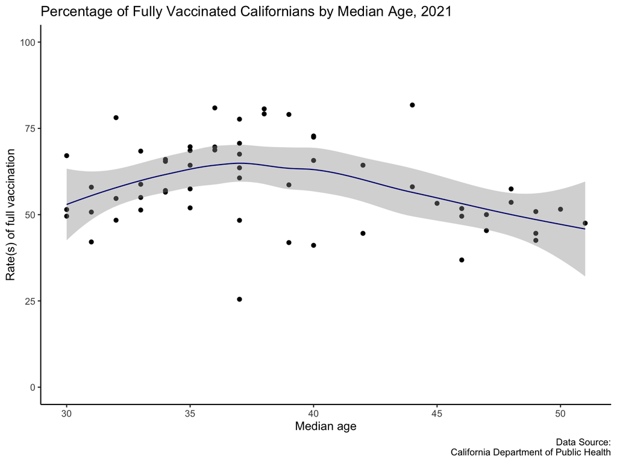

**Visualizations: Maps**

The map shows the rates of full vaccination, by county, symbolized by a color ramp (from low to high rates of vaccination going from yellow to dark red). A color ramp was made with classes of 10 percent each. A second map shows the median age of each country, symbolized by a purple color ramp (younger to older median age going from light purple to darker purple). The five-step color ramp ranges from 30 to 55, with each step covering five years of age.

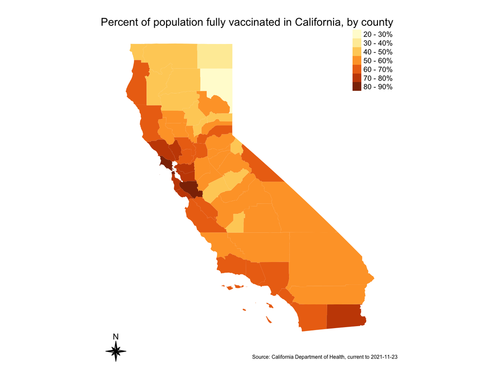

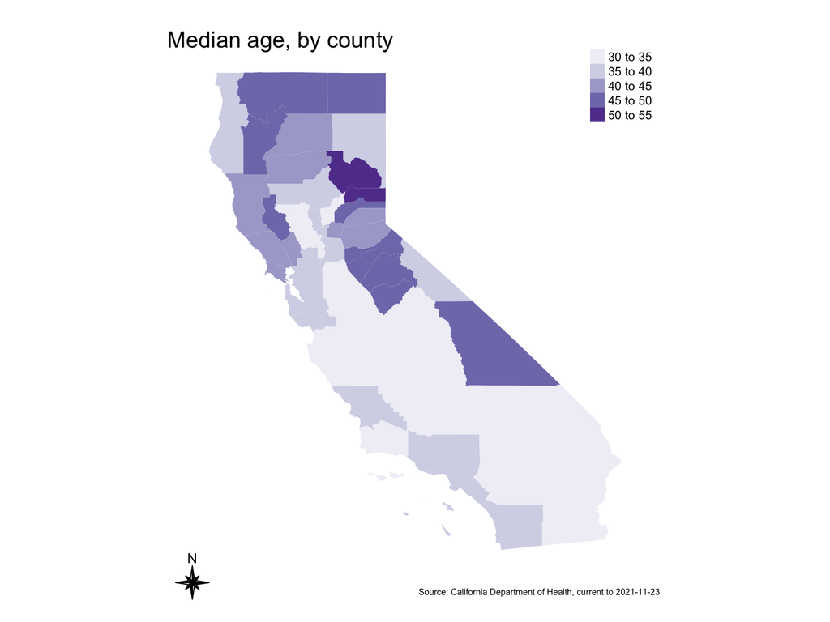

**Visualizations: Longitudinal Plot**

This last visualization features points plotted by month and percent of full vaccination in aggregate ZIP codes falling under four categories of the Vaccine Equity Metric (VEM) quartiles, which is based on demographic indicators of socioeconomic disadvantage and health vulnerability (where 1 is least disadvantaged/vulnerable and 4 and most disadvantaged/vulnerable).

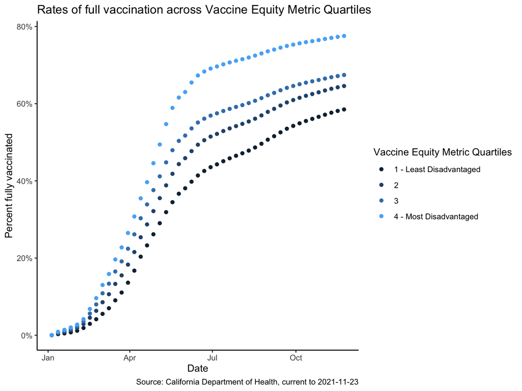

**Interpretation of Results**

According to our results, the minimum median age of persons receiving COVID-19 Vaccination in the state of California is 30, for Merced county. The maximum median age was found to be 51 in Sierra county. The overall median for the state of California is 38. A wide range of ages was seen in the overall analysis.

**Interpretation of Results**

Overall, there does not seem to be a strong linear relationship between median age and rates of full vaccination across California counties. Further statistical analysis would be needed to establish a robust correlative relationship between the two.

In terms of geography, higher vaccination rates were seen in counties such as San Francisco, Santa Clara, and Marin county with full vaccination rates at or above 80% and median ages of 38, 36, 44, respectively. Trailing behind are the counties of Alameda, Contra Costa, Imperial, and San Mateo with median ages of, 37, 38, 32, 39.

**Challenges**

*Understanding and addressing confusing data*

Some ZIPs had abnormally high vaccination totals compared to their population totals (sometimes having rates higher than 100%); we had to better understand where this data anomaly came from (e.g. some people chose to vaccinate outside of their home ZIP, therefore seemingly inflating numbers) and how to address it. In the end, no observations were removed due to this issue. rather, we aggregated vaccination numbers at the county level, acknowledging that the vaccinated population is still captured accurately at a larger geography in comparison to the total population.

*Working with a live dataset*

Changes in column names, vaccination eligible age, and temporality of data provided an extra layer of consideration when we were devising code that could be replicable and current to the updating dataset without maintenance. We addressed this by creating variables that returned the latest date using the *lubridate* package to ensure the results and visualizations would be up-to-date every time the .rmd was ran without manual user intervention.

**Something new we learned**

*Making maps with R*

The process of making maps with R is greatly simplified with the ability to treat geographic objects (shapefiles) as dataframes and/or dplyr-compatible tibbles. This meant that county-level data was easily appended to geographic geometry. The process of visualizing this data drew heavily upon the coursework in visualization (e.g.ggplot, table creation) and was intuitive.

*Making HTML slides with R*

Creation of visually-appealing and easy to navigate slidedecks through .rmd files with the slidy-presentation preset.